[figure not shown]

# Introduction to Neural Networks: Plants Seedling Classification

## Project #8

# Background and Context

In recent times, the field of agriculture has been in urgent need of modernizing, since the amount of manual work people need to put in to check if plants are growing correctly is still highly extensive. Despite several advances in agricultural technology, people working in the agricultural industry still need to have the ability to sort and recognize different plants and weeds, which takes a lot of time and effort in the long term.

The potential is ripe for this trillion-dollar industry to be greatly impacted by technological innovations that cut down on the requirement for manual labor, and this is where Artificial Intelligence can benefit the workers in this field, as the time and energy required to identify plant seedlings will be greatly shortened by the use of AI and Deep Learning. The ability to do so far more efficiently and even more effectively than experienced manual labor could lead to better crop yields, the freeing up of human involvement for higher-order agricultural decision making, and in the long term will result in more sustainable environmental practices in agriculture as well.

# Objective

The Aarhus University Signal Processing group, in collaboration with the University of Southern Denmark, has provided the data containing images of unique plants belonging to 12 different species. You being a data scientist, need to build a Convolutional Neural Network model which would classify the plant seedlings into their respective 12 categories.

# Data Description

This dataset contains images of unique plants belonging to 12 different species.

- The data file names are:
  - images.npy
  - Label.csv
- Due to the large volume of data, the images were converted to numpy arrays and stored in images.npy file and the corresponding labels are also put into Labels.csv so that you can work on the data/project seamlessly without having to worry about the high data volume.
- The goal of the project is to create a classifier capable of determining a plant's species from an image.

# Plant Species

- Black-grass
- Charlock
- Cleavers
- Common Chickweed
- Common Wheat
- Fat Hen
- Loose Silky-bent
- Maize
- Scentless Mayweed
- Shepherds Purse
- Small-flowered Cranesbill
- Sugar beet

# Question to Answer

1. What CNN (and optional settings and augmentatioins) will achieve the highest accuracy on this image recognition task

# Import Libraries

```python
# Import the time library so that the amount of time this notebook takes to run can be processed
import time

begin_total = time.time()
```

```python
# Import the necessary other libraries and setting certain settings for this notebook to run to compltion

# suppress warnings
import warnings
warnings.filterwarnings("ignore")

# primary data manipulation libraries
import os                                         # Common Python library for working with the Operating System
import math                                       # Common Python library for perfoming math opertions
import random                                     # Common Python library for generating random numbers
import cv2                                        # openCV for processing images
import pandas as pd                               # Pandas for loading data
import numpy as np                                # Numpy for Matrix operations

# data visualization libraries
import matplotlib.pyplot as plt                   # MatPlotLib for plotting and visualizations
import seaborn as sns                             # Seaborn for generating graphs


# tensorflow libraries
import tensorflow as tf
from tensorflow import keras

# keras libraties
from keras.preprocessing.image import ImageDataGenerator
from keras.models import Sequential
from keras.layers import Dense, Input, Dropout, Flatten, Conv2D, MaxPooling2D, BatchNormalization
from keras.optimizers import Adam, SGD
from keras import backend
from keras.models import Model
from keras.applications.vgg16 import VGG16


#sklearn libraries
from sklearn import preprocessing
from sklearn.model_selection import train_test_split
from sklearn.metrics import confusion_matrix
from sklearn.utils import class_weight
from sklearn.preprocessing import LabelBinarizer

# Display images using OpenCV
from google.colab.patches import cv2_imshow

# remove number of displayed columns limit
pd.set_option("display.max_columns", None)

# set limit on the number of rows to display
pd.set_option("display.max_rows", 200)
```

# Connect to Google Colab

```python
# Connecting to Google Colab requires a manual intervention. That makes running the notebook end to end impossible.

from google.colab import drive
drive.mount('/content/drive')
```

# Load the data

```python
# Load Images and Labels
project_path = '/content/drive/My Drive/Colab Notebooks/09 - Introduction to Computer Vision/Project8/'
image_file = 'images.npy'
labels_file = 'Labels.csv'

data = np.load(project_path+image_file)
labels = pd.read_csv(project_path+labels_file)
```

```python
print(f"Shape of the images: {data.shape}")
print(f"Shape of the labels: {labels.shape}")
```

```
Shape of the images: (4750, 128, 128, 3)
Shape of the labels: (4750, 1)
```

```python
categories = np.unique(labels)
category_count = len(categories)
print(f"There are {category_count} Categories:")
for category in categories:
  print(f"- {category}")
```

```
There are 12 Categories:
- Black-grass
- Charlock
- Cleavers
- Common Chickweed
- Common wheat
- Fat Hen
- Loose Silky-bent
- Maize
- Scentless Mayweed
- Shepherds Purse
- Small-flowered Cranesbill
- Sugar beet
```

There are 4750 images of shape 128 x 128 x 3 and 4750 labels (all in a single column)

# Custom Functions Used in this Notebook

## plot_images

```python
def plot_images(images,labels):
  num_classes=12                                                                  # Number of Classes
  categories=np.unique(labels)
  keys=dict(labels['Label'])                                                      # Obtaing the unique classes from y_train
  rows = 3                                                                        # Defining number of rows=3
  cols = 4                                                                        # Defining number of columns=4
  fig = plt.figure(figsize=(10, 8))                                               # Defining the figure size to 10x8
  for i in range(cols):
      for j in range(rows):
          random_index = np.random.randint(0, len(labels))                        # Generating random indices from the data and plotting the images
          ax = fig.add_subplot(rows, cols, i * rows + j + 1)                      # Adding subplots with 3 rows and 4 columns
          ax.imshow(images[random_index, :])                                      # Plotting the image
          ax.set_title(keys[random_index])
  plt.show()
```

## new_model

```python
def new_model():
  backend.clear_session()

  np.random.seed(1)
  random.seed(1)
  tf.random.set_seed(1)
```

## Labeled_barplot

```python
# function to create labeled barplots

def labeled_barplot(data, feature, perc=False, v_ticks=True, n=None):
    """
    Barplot with percentage at the top

    data: dataframe
    feature: dataframe column
    perc: whether to display percentages instead of count (default is False)
    n: displays the top n category levels (default is None, i.e., display all levels)
    """

    total = len(data[feature])  # length of the column
    count = data[feature].nunique()
    if n is None:
        plt.figure(figsize=(count + 1, 5))
    else:
        plt.figure(figsize=(n + 1, 5))

    if v_ticks is True:
        plt.xticks(rotation=90, fontsize=15)

    ax = sns.countplot(
        data=data,
        x=feature,
        palette="Paired",
        order=data[feature].value_counts().index[:n].sort_values(),
    )

    for p in ax.patches:
        if perc == True:
            label = "{:.1f}%".format(
                100 * p.get_height() / total
            )  # percentage of each class of the category
        else:
            label = p.get_height()  # count of each level of the category

        x = p.get_x() + p.get_width() / 2  # width of the plot
        y = p.get_height()  # height of the plot

        ax.annotate(
            label,
            (x, y),
            ha="center",
            va="center",
            size=12,
            xytext=(0, 5),
            textcoords="offset points",
        )  # annotate the percentage

    plt.show()  # show the plot
```

# EDA

## A look at some of the images before any augmentations or other changes

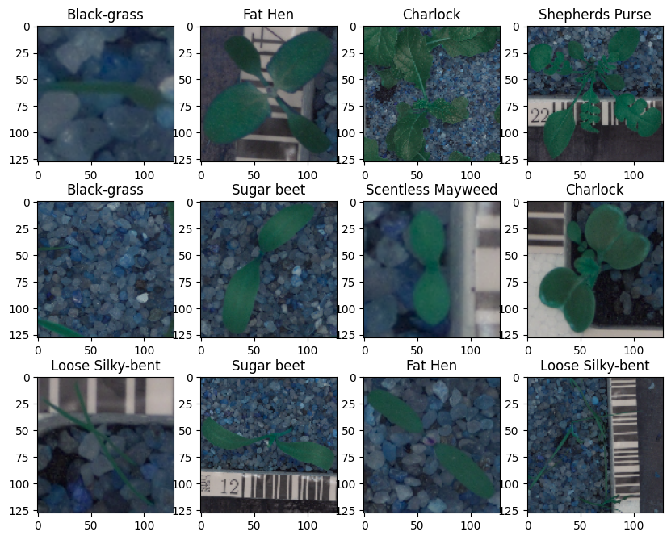

```python
plot_images(data, labels)
```

## Checking for Data imbalance

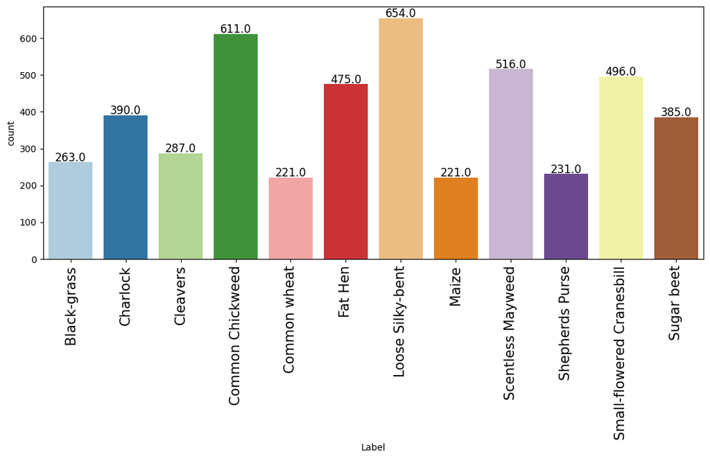

```python
labeled_barplot(labels, "Label")
```

Notes:

The data is imbalanced and will need to be augmented. Lose Silky-bent has the most values at 654

Need to add:

```
- Common wheat                      : 433
- Maize                             : 433
- Shepherds Purse                   : 423
- Black-grass                       : 391
- Cleavers                          : 367
- Sugar beet                        : 269
- Charlock                          : 264
- Fat Hen                           : 179
- Small-flowered Cranesbill         : 158
- Scentless Mayweed                 : 138
- Common Chickweed                  : 43
```

# Preprocessing the data

## Examining an Original Image

```python
image_number = 15
```

```
Original Image
```

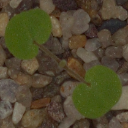

```python
print("Original Image")
cv2_imshow(data[image_number])
```

## Resize and GaussianBlur

```python
img_resized = cv2.resize(data[image_number], None, fx = 0.5, fy = 0.5)

img_resized_gb = cv2.GaussianBlur(img_resized, (3,3), 0)

print("\nResized Image")
cv2_imshow(img_resized)

print("\nResized and GaussianBlur")
cv2_imshow(img_resized_gb)
```

[output not shown]

```
Resized Image
```

```
Resized and GaussianBlur
```

## Convert to HSV

```python
img_hsv = cv2.cvtColor(img_resized_gb, cv2.COLOR_BGR2HSV)
cv2_imshow(img_hsv)
```

[output not shown]

## Mask all colors exept green

```python
l_green = (25, 40, 50)
h_green = (75, 255, 255)
mask = cv2.inRange(img_hsv, l_green, h_green)
kernel = cv2.getStructuringElement(cv2.MORPH_ELLIPSE, (11,11))
mask = cv2.morphologyEx(mask, cv2.MORPH_CLOSE, kernel)

isMasked = mask > 0
clear_image = np.zeros_like(img_resized, np.uint8)
clear_image[isMasked] = img_resized[isMasked]

cv2_imshow(clear_image)
```

[output not shown]

### Note:

This is the goal, to get all of the backgound out of the equation and then covert what is left of the green color to grayscale to simplify the analyis

## Apply Resize, Gaussian Blur, and Mask on a copy of all images

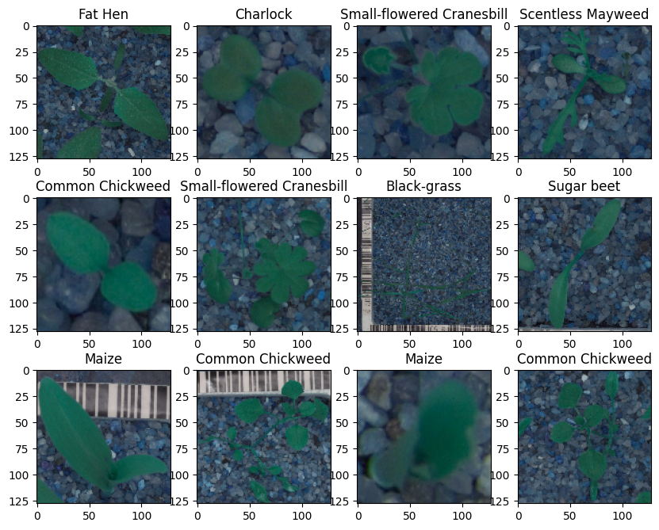

```python
# Output a sample of the original images
plot_images(data, labels)
```

```python
data_copy = data.copy()
preprocessed_data = []
```

```python
# Loop through all the images in the images array and transform the images to
# be simpler, smaller, and the correct format

for image in data:
  resized = cv2.resize(image, None, fx=0.5, fy=0.5)
  gb = cv2.GaussianBlur(resized, (3,3), 0)
  hsv = cv2.cvtColor(gb, cv2.COLOR_BGR2HSV)
  masked = cv2.inRange(hsv, l_green, h_green)
  masked = cv2.morphologyEx(masked, cv2.MORPH_CLOSE, kernel)
  imgMask = masked > 0
  clearImg = np.zeros_like(resized, np.uint8)
  clearImg[imgMask] = resized[imgMask]
  preprocessed_data.append(clearImg)

preprocessed_data = np.asarray(preprocessed_data)
```

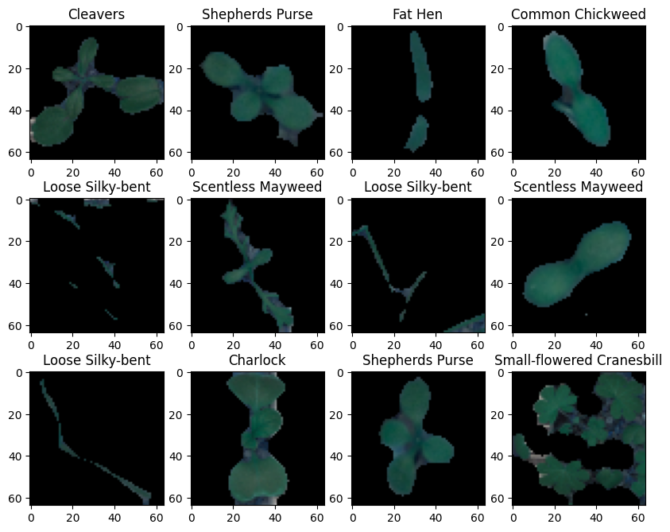

```python
# Output a sample of the modified images
plot_images(preprocessed_data, labels)
```

```python
preprocessed_data.shape
```

```
(4750, 64, 64, 3)
```

## Converting Color to Grayscale

```python
preprocessed_data_grayscale = []

for image in preprocessed_data:
  gray_image = cv2.cvtColor(image, cv2.COLOR_BGR2GRAY)
  preprocessed_data_grayscale.append(gray_image)

preprocessed_data_grayscale = np.asarray(preprocessed_data_grayscale)
```

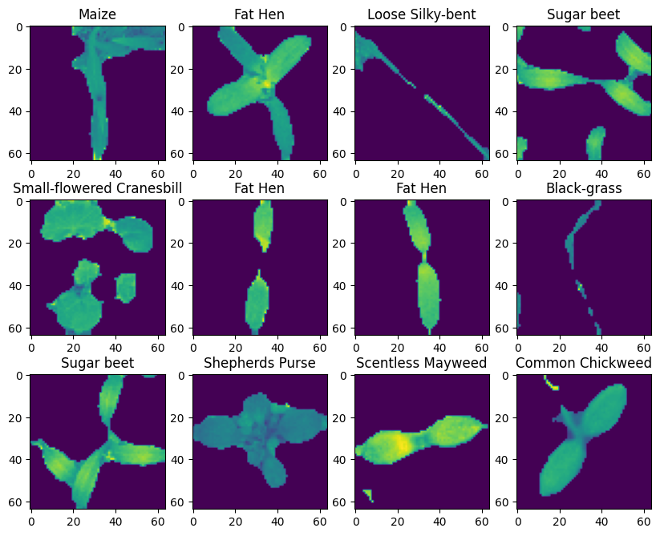

```python
plot_images(preprocessed_data_grayscale, labels)
```

```python
preprocessed_data_grayscale.shape
```

```
(4750, 64, 64)
```

### Notes:

We have converted the original image from a color image with a confusing background to a grayscale image with the background removed. The goal of this is to be able to focus on only what is important about the image

The image was also resized to be 1/2 the original to make processing faster

# Splitting the dataset

## Starting with the Color Images

```python
X_temp, X_test, y_temp, y_test = train_test_split(preprocessed_data,labels, test_size=0.2, random_state=1,stratify=labels)
X_train, X_val, y_train, y_val = train_test_split(X_temp,y_temp , test_size=0.2, random_state=1,stratify=y_temp)
```

```python
print(f"X_train: {X_train.shape}")
print(f"y_train: {y_train.shape}")
print("-"*50)
print(f"X_val  : {X_val.shape}")
print(f"y_val  : {y_val.shape}")
print("-"*50)
print(f"X_test : {X_test.shape}")
print(f"y_test : {y_test.shape}")
```

```
X_train: (3040, 64, 64, 3)
y_train: (3040, 1)
--------------------------------------------------
X_val  : (760, 64, 64, 3)
y_val  : (760, 1)
--------------------------------------------------
X_test : (950, 64, 64, 3)
y_test : (950, 1)
```

## Define the class weights since there is an imbalance in the classes

```python
labelList = labels.Label.unique()
class_weights = class_weight.compute_class_weight(class_weight = "balanced",
                                                  classes = np.array(labelList),
                                                  y = y_train.values.reshape(-1)
                                                  )
class_weights = dict(zip(np.array(range(len(labelList))), class_weights))
#print calculated class weights
class_weights
```

```
{0: 0.7966457023060797,
 1: 0.8333333333333334,
 2: 1.7117117117117118,
 3: 1.784037558685446,
 4: 0.6479113384484229,
 5: 1.0133333333333334,
 6: 1.384335154826958,
 7: 0.7676767676767676,
 8: 1.029810298102981,
 9: 1.784037558685446,
 10: 1.507936507936508,
 11: 0.6060606060606061}
```

## Enconding the target labels

```python
enc = LabelBinarizer()
y_train_encoded = enc.fit_transform(y_train)
y_val_encoded=enc.transform(y_val)
y_test_encoded=enc.transform(y_test)
```

```python
print(f"y_train_encoded shape: {y_train_encoded.shape}")
print(f"y_val_encoded shape:   {y_val_encoded.shape}")
print(f"y_test_encoded shape:  {y_test_encoded.shape}")
```

```
y_train_encoded shape: (3040, 12)
y_val_encoded shape:   (760, 12)
y_test_encoded shape:  (950, 12)
```

## Normalization

```python
X_train_normalized = X_train.astype('float32')/255.0
X_val_normalized = X_val.astype('float32')/255.0
X_test_normalized = X_test.astype('float32')/255.0
```

# Model 1 : Shrunken Images

```python
new_model()
```

```python
model1 = Sequential()

#Input Layer
model1.add(Conv2D(64, (3,3), activation='relu', padding='same', input_shape=(64, 64, 3)))

# Add MaxPooling an additional convolutional layer and then pooling a second time
model1.add(MaxPooling2D((2, 2), padding = 'same'))
model1.add(Conv2D(32, (3,3), activation='relu', padding='same'))
model1.add(MaxPooling2D((2, 2), padding = 'same'))

# Flatten
model1.add(Flatten())

# Adding Fully Connected Hidden Layer
model1.add(Dense(16, activation='relu'))
model1.add(Dropout(0.3))

# Output Layer
model1.add(Dense(12, activation='softmax'))

optimizer = Adam()

model1.compile(optimizer=optimizer, loss='categorical_crossentropy', metrics=['accuracy'])

model1.summary()
```

```
Model: "sequential"
_________________________________________________________________
 Layer (type)                Output Shape              Param #
=================================================================
 conv2d (Conv2D)             (None, 64, 64, 64)        1792

 max_pooling2d (MaxPooling2D  (None, 32, 32, 64)       0
 )

 conv2d_1 (Conv2D)           (None, 32, 32, 32)        18464

 max_pooling2d_1 (MaxPooling  (None, 16, 16, 32)       0
 2D)

 flatten (Flatten)           (None, 8192)              0

 dense (Dense)               (None, 16)                131088

 dropout (Dropout)           (None, 16)                0

 dense_1 (Dense)             (None, 12)                204

=================================================================
Total params: 151,548
Trainable params: 151,548
Non-trainable params: 0
_________________________________________________________________
```

## Fit the model on the train data with the class_weights

```python
history1 = model1.fit(
    X_train_normalized, y_train_encoded,
    epochs=30,
    validation_data=(X_val_normalized, y_val_encoded),
    class_weight=class_weights,
    batch_size=32,
    verbose=2
)
```

```
95/95 - 4s - loss: 2.6348 - accuracy: 0.2283 - val_loss: 1.9463 - val_accuracy: 0.3579 - 4s/epoch - 40ms/step
95/95 - 0s - loss: 2.0911 - accuracy: 0.3454 - val_loss: 1.7167 - val_accuracy: 0.3921 - 332ms/epoch - 3ms/step
95/95 - 0s - loss: 1.8125 - accuracy: 0.4171 - val_loss: 1.4423 - val_accuracy: 0.5118 - 342ms/epoch - 4ms/step
95/95 - 0s - loss: 1.6312 - accuracy: 0.4595 - val_loss: 1.4237 - val_accuracy: 0.5303 - 345ms/epoch - 4ms/step
95/95 - 0s - loss: 1.5143 - accuracy: 0.4921 - val_loss: 1.2620 - val_accuracy: 0.5921 - 344ms/epoch - 4ms/step
95/95 - 0s - loss: 1.3922 - accuracy: 0.5253 - val_loss: 1.2589 - val_accuracy: 0.5882 - 341ms/epoch - 4ms/step
95/95 - 0s - loss: 1.3006 - accuracy: 0.5559 - val_loss: 1.1656 - val_accuracy: 0.6118 - 353ms/epoch - 4ms/step
95/95 - 0s - loss: 1.2474 - accuracy: 0.5572 - val_loss: 1.1529 - val_accuracy: 0.6118 - 346ms/epoch - 4ms/step
95/95 - 0s - loss: 1.2027 - accuracy: 0.5763 - val_loss: 1.1457 - val_accuracy: 0.6329 - 346ms/epoch - 4ms/step
95/95 - 0s - loss: 1.1282 - accuracy: 0.6072 - val_loss: 1.1120 - val_accuracy: 0.6329 - 352ms/epoch - 4ms/step
95/95 - 0s - loss: 1.0512 - accuracy: 0.6194 - val_loss: 1.1123 - val_accuracy: 0.6276 - 342ms/epoch - 4ms/step
95/95 - 0s - loss: 0.9791 - accuracy: 0.6434 - val_loss: 1.1531 - val_accuracy: 0.6237 - 343ms/epoch - 4ms/step
95/95 - 0s - loss: 0.9948 - accuracy: 0.6359 - val_loss: 1.0859 - val_accuracy: 0.6500 - 355ms/epoch - 4ms/step
95/95 - 0s - loss: 0.9223 - accuracy: 0.6523 - val_loss: 1.1078 - val_accuracy: 0.6553 - 344ms/epoch - 4ms/step
95/95 - 0s - loss: 0.8646 - accuracy: 0.6658 - val_loss: 1.0948 - val_accuracy: 0.6658 - 338ms/epoch - 4ms/step
95/95 - 0s - loss: 0.8482 - accuracy: 0.6793 - val_loss: 1.0667 - val_accuracy: 0.6553 - 337ms/epoch - 4ms/step
95/95 - 0s - loss: 0.8435 - accuracy: 0.6822 - val_loss: 1.0511 - val_accuracy: 0.6737 - 335ms/epoch - 4ms/step
95/95 - 0s - loss: 0.8218 - accuracy: 0.6816 - val_loss: 1.1569 - val_accuracy: 0.6526 - 335ms/epoch - 4ms/step
95/95 - 0s - loss: 0.7717 - accuracy: 0.7079 - val_loss: 1.1210 - val_accuracy: 0.6592 - 339ms/epoch - 4ms/step
95/95 - 0s - loss: 0.7734 - accuracy: 0.7099 - val_loss: 1.0929 - val_accuracy: 0.6697 - 332ms/epoch - 3ms/step
95/95 - 0s - loss: 0.7630 - accuracy: 0.7171 - val_loss: 1.2070 - val_accuracy: 0.6579 - 332ms/epoch - 3ms/step
95/95 - 0s - loss: 0.7112 - accuracy: 0.7418 - val_loss: 1.1458 - val_accuracy: 0.6671 - 341ms/epoch - 4ms/step
95/95 - 0s - loss: 0.7334 - accuracy: 0.7122 - val_loss: 1.2251 - val_accuracy: 0.6579 - 331ms/epoch - 3ms/step
95/95 - 0s - loss: 0.7016 - accuracy: 0.7286 - val_loss: 1.1760 - val_accuracy: 0.6645 - 329ms/epoch - 3ms/step
95/95 - 0s - loss: 0.6843 - accuracy: 0.7391 - val_loss: 1.2529 - val_accuracy: 0.6776 - 333ms/epoch - 4ms/step
95/95 - 0s - loss: 0.6773 - accuracy: 0.7444 - val_loss: 1.3941 - val_accuracy: 0.6487 - 331ms/epoch - 3ms/step
95/95 - 0s - loss: 0.7074 - accuracy: 0.7299 - val_loss: 1.3035 - val_accuracy: 0.6750 - 333ms/epoch - 4ms/step
95/95 - 0s - loss: 0.6637 - accuracy: 0.7388 - val_loss: 1.3853 - val_accuracy: 0.6658 - 337ms/epoch - 4ms/step
95/95 - 0s - loss: 0.6571 - accuracy: 0.7516 - val_loss: 1.2869 - val_accuracy: 0.6618 - 328ms/epoch - 3ms/step
95/95 - 0s - loss: 0.6593 - accuracy: 0.7516 - val_loss: 1.3536 - val_accuracy: 0.6658 - 328ms/epoch - 3ms/step
```

## Model1 Evaluation

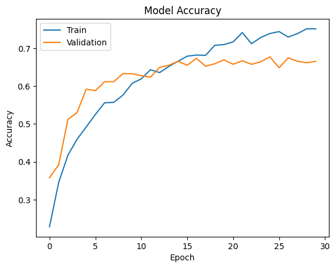

```python
plt.plot(history1.history['accuracy'])
plt.plot(history1.history['val_accuracy'])
plt.title('Model Accuracy')
plt.ylabel('Accuracy')
plt.xlabel('Epoch')
plt.legend(['Train', 'Validation'], loc='upper left')
plt.show()
```

### Notes:

- The accuracy of train never got much more than 75% and while validation was slightly less there looks to be some overfitting that is starting

```python
accuracy1 = model1.evaluate(X_test_normalized, y_test_encoded, verbose=2)
```

```
30/30 - 0s - loss: 1.5298 - accuracy: 0.6168 - 132ms/epoch - 4ms/step
```

## Prediction based on test data

```python
y_pred=model1.predict(X_test_normalized)
```

```python
y_pred
```

```
array([[3.08735082e-19, 1.75325169e-07, 1.09789568e-07, ...,
        1.75453228e-04, 9.99732912e-01, 8.18317582e-13],
       [1.52955025e-01, 2.49311453e-25, 1.06953368e-18, ...,
        6.33336652e-20, 7.28208730e-16, 4.96062802e-10],
       [3.44625307e-16, 2.68370877e-05, 3.74492106e-06, ...,
        5.45266230e-05, 9.99373257e-01, 1.10205578e-09],
       ...,
       [1.24145516e-09, 6.31206404e-13, 1.22108501e-09, ...,
        1.67541730e-05, 6.00105921e-08, 1.52598223e-09],
       [1.93690974e-03, 1.75281361e-01, 1.57112762e-01, ...,
        1.46786153e-01, 1.05304215e-02, 1.18172683e-01],
       [1.25687639e-05, 6.61214394e-03, 9.72035408e-01, ...,
        5.63379726e-04, 1.38618358e-04, 9.81210633e-06]], dtype=float32)
```

## Prediction Confusion Matrix

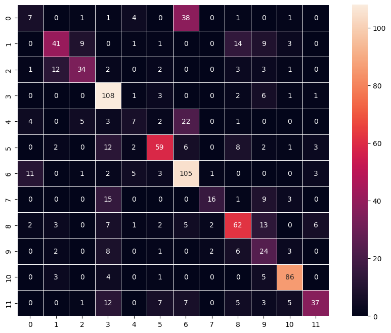

```python
y_pred_arg=np.argmax(y_pred, axis=1)
y_test_arg=np.argmax(y_test_encoded, axis=1)

confusion_matrix = tf.math.confusion_matrix(y_test_arg, y_pred_arg)
f, ax = plt.subplots(figsize=(12,8))
sns.heatmap(
    confusion_matrix, annot=True, linewidths=.4,
    fmt='d', square=True, ax=ax
)
plt.show()
```

### Notes:

- There are a lot of classes that are not predicted correctly
- Class 3 and 6 have the highest classification
- Clases 0, 4, 7, 9 & 11 had the fewest correctly classified images

## Model1 Conclusion

- This model looks to be overfit and in not a good model for prediction

# Model 2 : Data Augmentation

```python
new_model()
```

## Data Augmentation

```python
batch_size = 32
seed = 1
shuffle = True

train_data_aug = ImageDataGenerator(
                              horizontal_flip = True,
                              vertical_flip = True,
                              height_shift_range = 0.1,
                              width_shift_range = 0.1,
                              rotation_range=90,
                              shear_range = 0.2,
                              zoom_range = 0.1,
                              )

training_generator = train_data_aug.flow(X_train_normalized,y_train_encoded,
                                       batch_size=batch_size,
                                       seed=seed,
                                       shuffle=shuffle)
```

## Some Examples of the Augmented images

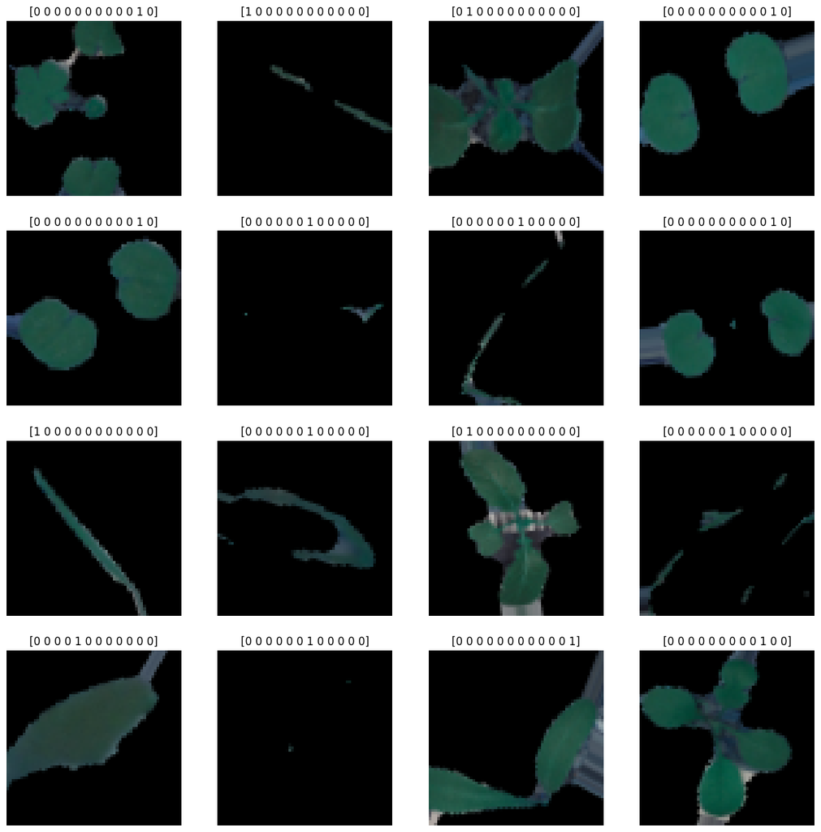

```python
images, data_labels = next(training_generator)
fig, axes = plt.subplots(4,4, figsize= (16,8))
fig.set_size_inches(16,16)
for (image, label, ax) in zip(images, data_labels, axes.flatten()):
  ax.imshow(image)
  ax.set_title(label)
  ax.axis('off')
```

```python
model2 = Sequential()

#Input Layer
model2.add(Conv2D(32, (3,3), activation='relu', padding='same', input_shape=(64, 64, 3)))
# Add MaxPooling an additional convolutional layer and then pooling a second time
model2.add(BatchNormalization())
model2.add(MaxPooling2D((2, 2), padding = 'same'))

# Add a second convolution layer
model2.add(Conv2D(64, (3,3), activation='relu', padding='same'))
model2.add(BatchNormalization())
model2.add(MaxPooling2D((2, 2), padding = 'same'))

# Add a third convolution layer
model2.add(Conv2D(64, (3,3), activation='relu', padding='valid'))
model2.add(BatchNormalization())
model2.add(MaxPooling2D((2, 2), padding = 'same'))

# Flatten
model2.add(Flatten())

# Adding the first fully connected hidden layer
model2.add(Dense(512, activation='relu'))
model2.add(Dropout(0.2))


# Adding a second fully connected hidden layer
model2.add(Dense(128, activation='relu'))
model2.add(Dropout(0.2))

# Output Layer
model2.add(Dense(12, activation='softmax'))

optimizer = Adam(learning_rate=0.001)

model2.compile(optimizer=optimizer, loss='categorical_crossentropy', metrics=['accuracy'])

model2.summary()
```

```
Model: "sequential"
_________________________________________________________________
 Layer (type)                Output Shape              Param #
=================================================================
 conv2d (Conv2D)             (None, 64, 64, 32)        896

 batch_normalization (BatchN  (None, 64, 64, 32)       128
 ormalization)

 max_pooling2d (MaxPooling2D  (None, 32, 32, 32)       0
 )

 conv2d_1 (Conv2D)           (None, 32, 32, 64)        18496

 batch_normalization_1 (Batc  (None, 32, 32, 64)       256
 hNormalization)

 max_pooling2d_1 (MaxPooling  (None, 16, 16, 64)       0
 2D)

 conv2d_2 (Conv2D)           (None, 14, 14, 64)        36928

 batch_normalization_2 (Batc  (None, 14, 14, 64)       256
 hNormalization)

 max_pooling2d_2 (MaxPooling  (None, 7, 7, 64)         0
 2D)

 flatten (Flatten)           (None, 3136)              0

 dense (Dense)               (None, 512)               1606144

 dropout (Dropout)           (None, 512)               0

 dense_1 (Dense)             (None, 128)               65664

 dropout_1 (Dropout)         (None, 128)               0

 dense_2 (Dense)             (None, 12)                1548

=================================================================
Total params: 1,730,316
Trainable params: 1,729,996
Non-trainable params: 320
_________________________________________________________________
```

## Fit the model on the train data with the class_weights and early stopping

```python
callback_escape = keras.callbacks.EarlyStopping(monitor='val_accuracy',
                                                patience=20,
                                                min_delta=0.0001,
                                                restore_best_weights=True
                                              )

batch_size = 32
epochs = 150
```

```python
history2 = model2.fit(
    training_generator,
    epochs=epochs,
    validation_data=(X_val_normalized, y_val_encoded),
    class_weight=class_weights,
    shuffle=True,
    verbose=2,
    callbacks = [callback_escape]
)
```

```
95/95 - 5s - loss: 2.3840 - accuracy: 0.3487 - val_loss: 6.3803 - val_accuracy: 0.0605 - 5s/epoch - 49ms/step
95/95 - 4s - loss: 1.6707 - accuracy: 0.4572 - val_loss: 14.8847 - val_accuracy: 0.0605 - 4s/epoch - 37ms/step
95/95 - 4s - loss: 1.4599 - accuracy: 0.5240 - val_loss: 26.8575 - val_accuracy: 0.0605 - 4s/epoch - 39ms/step
95/95 - 4s - loss: 1.3143 - accuracy: 0.5799 - val_loss: 28.0196 - val_accuracy: 0.0605 - 4s/epoch - 37ms/step
95/95 - 4s - loss: 1.2539 - accuracy: 0.6099 - val_loss: 17.7870 - val_accuracy: 0.0605 - 4s/epoch - 37ms/step
95/95 - 4s - loss: 1.1750 - accuracy: 0.6257 - val_loss: 2.5388 - val_accuracy: 0.4250 - 4s/epoch - 37ms/step
95/95 - 4s - loss: 1.0525 - accuracy: 0.6697 - val_loss: 1.9608 - val_accuracy: 0.5487 - 4s/epoch - 38ms/step
95/95 - 4s - loss: 0.9912 - accuracy: 0.6934 - val_loss: 1.5062 - val_accuracy: 0.5737 - 4s/epoch - 37ms/step
95/95 - 4s - loss: 0.9394 - accuracy: 0.7043 - val_loss: 1.0792 - val_accuracy: 0.6618 - 4s/epoch - 37ms/step
95/95 - 4s - loss: 0.9156 - accuracy: 0.7158 - val_loss: 0.9965 - val_accuracy: 0.6947 - 4s/epoch - 37ms/step
95/95 - 4s - loss: 0.8136 - accuracy: 0.7421 - val_loss: 0.6864 - val_accuracy: 0.7553 - 4s/epoch - 37ms/step
95/95 - 4s - loss: 0.8029 - accuracy: 0.7434 - val_loss: 1.6598 - val_accuracy: 0.5921 - 4s/epoch - 37ms/step
95/95 - 4s - loss: 0.7434 - accuracy: 0.7595 - val_loss: 1.5418 - val_accuracy: 0.6171 - 4s/epoch - 37ms/step
95/95 - 4s - loss: 0.6940 - accuracy: 0.7766 - val_loss: 0.6831 - val_accuracy: 0.7697 - 4s/epoch - 38ms/step
95/95 - 4s - loss: 0.6947 - accuracy: 0.7806 - val_loss: 1.2607 - val_accuracy: 0.6974 - 4s/epoch - 37ms/step
95/95 - 4s - loss: 0.6738 - accuracy: 0.7766 - val_loss: 1.2671 - val_accuracy: 0.6789 - 4s/epoch - 37ms/step
95/95 - 4s - loss: 0.6285 - accuracy: 0.7954 - val_loss: 0.6422 - val_accuracy: 0.7934 - 4s/epoch - 37ms/step
95/95 - 4s - loss: 0.6408 - accuracy: 0.7967 - val_loss: 1.1320 - val_accuracy: 0.6961 - 4s/epoch - 38ms/step
95/95 - 4s - loss: 0.6239 - accuracy: 0.7970 - val_loss: 1.8705 - val_accuracy: 0.5803 - 4s/epoch - 37ms/step
95/95 - 4s - loss: 0.5629 - accuracy: 0.8155 - val_loss: 0.5755 - val_accuracy: 0.8211 - 4s/epoch - 37ms/step
95/95 - 4s - loss: 0.5561 - accuracy: 0.8211 - val_loss: 2.0542 - val_accuracy: 0.5803 - 4s/epoch - 37ms/step
95/95 - 3s - loss: 0.5264 - accuracy: 0.8260 - val_loss: 1.1825 - val_accuracy: 0.6592 - 3s/epoch - 37ms/step
95/95 - 4s - loss: 0.5401 - accuracy: 0.8247 - val_loss: 0.4031 - val_accuracy: 0.8579 - 4s/epoch - 37ms/step
95/95 - 4s - loss: 0.5186 - accuracy: 0.8240 - val_loss: 0.6691 - val_accuracy: 0.7961 - 4s/epoch - 37ms/step
95/95 - 4s - loss: 0.4988 - accuracy: 0.8408 - val_loss: 0.8277 - val_accuracy: 0.7566 - 4s/epoch - 37ms/step
95/95 - 4s - loss: 0.4628 - accuracy: 0.8428 - val_loss: 0.5583 - val_accuracy: 0.8329 - 4s/epoch - 37ms/step
95/95 - 4s - loss: 0.4894 - accuracy: 0.8368 - val_loss: 0.6181 - val_accuracy: 0.8118 - 4s/epoch - 37ms/step
95/95 - 4s - loss: 0.4907 - accuracy: 0.8421 - val_loss: 0.6425 - val_accuracy: 0.8013 - 4s/epoch - 37ms/step
95/95 - 4s - loss: 0.4272 - accuracy: 0.8622 - val_loss: 0.5272 - val_accuracy: 0.8395 - 4s/epoch - 37ms/step
95/95 - 4s - loss: 0.4434 - accuracy: 0.8441 - val_loss: 0.3408 - val_accuracy: 0.8776 - 4s/epoch - 37ms/step
95/95 - 4s - loss: 0.4665 - accuracy: 0.8408 - val_loss: 0.8292 - val_accuracy: 0.7724 - 4s/epoch - 37ms/step
95/95 - 4s - loss: 0.4364 - accuracy: 0.8549 - val_loss: 0.6021 - val_accuracy: 0.7947 - 4s/epoch - 37ms/step
95/95 - 3s - loss: 0.3943 - accuracy: 0.8602 - val_loss: 1.3518 - val_accuracy: 0.6592 - 3s/epoch - 37ms/step
95/95 - 4s - loss: 0.4331 - accuracy: 0.8576 - val_loss: 0.4228 - val_accuracy: 0.8526 - 4s/epoch - 37ms/step
95/95 - 4s - loss: 0.4170 - accuracy: 0.8609 - val_loss: 0.9596 - val_accuracy: 0.7724 - 4s/epoch - 38ms/step
95/95 - 4s - loss: 0.3896 - accuracy: 0.8618 - val_loss: 1.5806 - val_accuracy: 0.6500 - 4s/epoch - 37ms/step
95/95 - 4s - loss: 0.4170 - accuracy: 0.8539 - val_loss: 0.3997 - val_accuracy: 0.8579 - 4s/epoch - 37ms/step
95/95 - 4s - loss: 0.3738 - accuracy: 0.8720 - val_loss: 1.0711 - val_accuracy: 0.7408 - 4s/epoch - 37ms/step
95/95 - 4s - loss: 0.4247 - accuracy: 0.8556 - val_loss: 0.5941 - val_accuracy: 0.8039 - 4s/epoch - 37ms/step
95/95 - 4s - loss: 0.3835 - accuracy: 0.8701 - val_loss: 0.5831 - val_accuracy: 0.7934 - 4s/epoch - 37ms/step
```

[output cut: 18 more lines]

```
95/95 - 4s - loss: 0.2919 - accuracy: 0.8997 - val_loss: 0.7013 - val_accuracy: 0.8092 - 4s/epoch - 37ms/step
95/95 - 4s - loss: 0.3344 - accuracy: 0.8845 - val_loss: 1.3498 - val_accuracy: 0.6684 - 4s/epoch - 37ms/step
95/95 - 4s - loss: 0.3088 - accuracy: 0.8878 - val_loss: 0.4476 - val_accuracy: 0.8566 - 4s/epoch - 37ms/step
95/95 - 4s - loss: 0.2820 - accuracy: 0.8990 - val_loss: 0.4608 - val_accuracy: 0.8803 - 4s/epoch - 37ms/step
95/95 - 4s - loss: 0.3124 - accuracy: 0.8928 - val_loss: 0.6177 - val_accuracy: 0.8145 - 4s/epoch - 38ms/step
95/95 - 4s - loss: 0.3055 - accuracy: 0.8901 - val_loss: 0.5076 - val_accuracy: 0.8382 - 4s/epoch - 37ms/step
95/95 - 4s - loss: 0.2937 - accuracy: 0.8928 - val_loss: 0.6820 - val_accuracy: 0.8263 - 4s/epoch - 37ms/step
95/95 - 4s - loss: 0.2982 - accuracy: 0.8984 - val_loss: 1.3444 - val_accuracy: 0.7066 - 4s/epoch - 38ms/step
95/95 - 4s - loss: 0.3206 - accuracy: 0.8859 - val_loss: 1.0632 - val_accuracy: 0.7039 - 4s/epoch - 37ms/step
95/95 - 4s - loss: 0.2727 - accuracy: 0.9003 - val_loss: 1.3068 - val_accuracy: 0.7092 - 4s/epoch - 37ms/step
95/95 - 4s - loss: 0.2838 - accuracy: 0.8987 - val_loss: 1.3071 - val_accuracy: 0.6421 - 4s/epoch - 37ms/step
95/95 - 4s - loss: 0.2963 - accuracy: 0.8951 - val_loss: 0.6071 - val_accuracy: 0.8079 - 4s/epoch - 38ms/step
95/95 - 4s - loss: 0.2821 - accuracy: 0.8938 - val_loss: 0.4134 - val_accuracy: 0.8789 - 4s/epoch - 37ms/step
95/95 - 4s - loss: 0.2590 - accuracy: 0.9118 - val_loss: 0.4703 - val_accuracy: 0.8605 - 4s/epoch - 37ms/step
95/95 - 4s - loss: 0.2845 - accuracy: 0.8970 - val_loss: 1.0913 - val_accuracy: 0.6974 - 4s/epoch - 38ms/step
```

## Model2 Evaluation

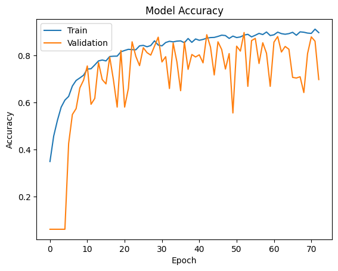

```python
plt.plot(history2.history['accuracy'])
plt.plot(history2.history['val_accuracy'])
plt.title('Model Accuracy')
plt.ylabel('Accuracy')
plt.xlabel('Epoch')
plt.legend(['Train', 'Validation'], loc='upper left')
plt.show()
```

### Notes:

- This model doesn't appear to be overfitting and achieved good accuract on both train and validation data

```python
accuracy2 = model2.evaluate(X_test_normalized, y_test_encoded)
print(f"test accuracy: {accuracy2}")
```

```
test accuracy: [0.4266490042209625, 0.8778947591781616]
```

```python
best_model_accuracy = history2.history['accuracy'][np.argmin(history2.history['loss'])]
print(f"best model accuracy (with the least loss): {best_model_accuracy}")
```

```
best model accuracy (with the least loss): 0.9118421077728271
```

## Prediction based on test data

```python
y_pred2 = model2.predict(X_test_normalized)
```

```python
y_pred2
```

```
array([[4.5669113e-18, 9.9075089e-07, 7.2518492e-07, ..., 2.0714377e-07,
        9.9999785e-01, 4.4056698e-12],
       [1.2167459e-02, 4.8551590e-07, 6.0305878e-04, ..., 5.5105870e-10,
        8.2301144e-10, 9.3346529e-08],
       [2.4294578e-18, 9.7344382e-06, 7.3063933e-07, ..., 3.9891477e-09,
        9.9998951e-01, 2.1143176e-12],
       ...,
       [5.7453954e-17, 2.7042924e-16, 2.5623747e-13, ..., 9.3710405e-06,
        2.3561262e-09, 7.2485273e-16],
       [1.8422548e-05, 2.6723577e-02, 9.5646834e-01, ..., 9.2475163e-03,
        2.0598530e-04, 3.4282297e-05],
       [6.6217605e-15, 1.9565870e-05, 9.9998045e-01, ..., 1.7736264e-11,
        8.0075080e-10, 1.5129446e-12]], dtype=float32)
```

## Prediction Confusion Matrix

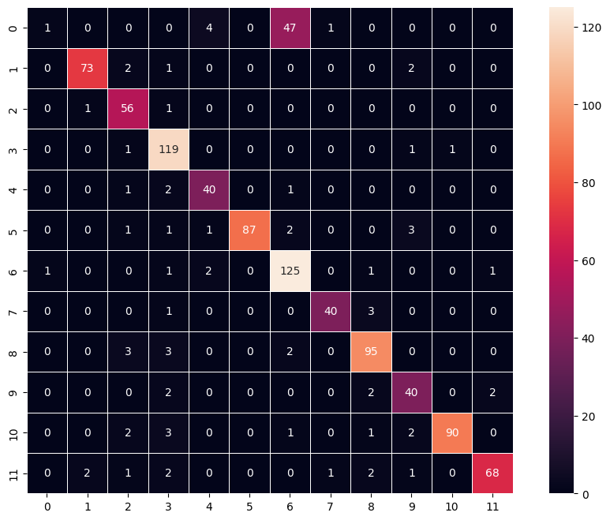

```python
y_pred2_arg=np.argmax(y_pred2, axis=1)
y_test2_arg=np.argmax(y_test_encoded, axis=1)

confusion_matrix2 = tf.math.confusion_matrix(y_test2_arg, y_pred2_arg)
f, ax = plt.subplots(figsize=(12,8))
sns.heatmap(
    confusion_matrix2, annot=True, linewidths=.4,
    fmt='d', square=True, ax=ax
)
plt.show()
```

### Notes:

- There is still one class that is not predicted correctly 0
- Class 6, 3, 8 & 10 have the highest correct classification

## Model2 Conclusion

- This model using color images looks to be a good model for prediction

## Model 3 - Grayscale images

## Split the grayscale data

```python
X_temp_gs, X_test_gs, y_temp_gs, y_test_gs = train_test_split(preprocessed_data_grayscale,labels, test_size=0.2, random_state=1,stratify=labels)
X_train_gs, X_val_gs, y_train_gs, y_val_gs = train_test_split(X_temp_gs,y_temp_gs , test_size=0.2, random_state=1,stratify=y_temp)
```

```python
print(f"X_train_gs: {X_train_gs.shape}")
print(f"y_train_gs: {y_train_gs.shape}")
print("-"*50)
print(f"X_val_gs  : {X_val_gs.shape}")
print(f"y_val_gs  : {y_val_gs.shape}")
print("-"*50)
print(f"X_test_gs : {X_test_gs.shape}")
print(f"y_test_gs : {y_test_gs.shape}")
```

```
X_train_gs: (3040, 64, 64)
y_train_gs: (3040, 1)
--------------------------------------------------
X_val_gs  : (760, 64, 64)
y_val_gs  : (760, 1)
--------------------------------------------------
X_test_gs : (950, 64, 64)
y_test_gs : (950, 1)
```

## Reshaping the data is now necessary

```python
X_train_gs = X_train_gs.reshape(X_train_gs.shape[0], 64, 64, 1)
X_val_gs = X_val_gs.reshape(X_val_gs.shape[0], 64, 64, 1)
X_test_gs = X_test_gs.reshape(X_test_gs.shape[0], 64, 64, 1)
```

## Getting the class_weights again since we split the data fresh

```python
labelList = labels.Label.unique()
class_weights = class_weight.compute_class_weight(class_weight = "balanced",
                                                  classes = np.array(labelList),
                                                  y = y_train_gs.values.reshape(-1)
                                                  )
class_weights = dict(zip(np.array(range(len(labelList))), class_weights))
#print calculated class weights
class_weights
```

```
{0: 0.7966457023060797,
 1: 0.8333333333333334,
 2: 1.7117117117117118,
 3: 1.784037558685446,
 4: 0.6479113384484229,
 5: 1.0133333333333334,
 6: 1.384335154826958,
 7: 0.7676767676767676,
 8: 1.029810298102981,
 9: 1.784037558685446,
 10: 1.507936507936508,
 11: 0.6060606060606061}
```

## Enconding the target labels

```python
enc = LabelBinarizer()
y_train_encoded_gs = enc.fit_transform(y_train_gs)
y_val_encoded_gs=enc.transform(y_val_gs)
y_test_encoded_gs=enc.transform(y_test_gs)
```

```python
print(f"y_train_encoded_gs shape: {y_train_encoded_gs.shape}")
print(f"y_val_encoded_gs shape:   {y_val_encoded_gs.shape}")
print(f"y_test_encoded_gs shape:  {y_test_encoded_gs.shape}")
```

```
y_train_encoded_gs shape: (3040, 12)
y_val_encoded_gs shape:   (760, 12)
y_test_encoded_gs shape:  (950, 12)
```

## Normalization

```python
X_train_normalized_gs = X_train_gs.astype('float32')/255.0
X_val_normalized_gs = X_val_gs.astype('float32')/255.0
X_test_normalized_gs = X_test_gs.astype('float32')/255.0
```

## Data Augmentation

```python
batch_size = 32
seed = 1
shuffle = True

train_data_aug = ImageDataGenerator(
                              horizontal_flip = True,
                              vertical_flip = True,
                              height_shift_range = 0.1,
                              width_shift_range = 0.1,
                              rotation_range=180,
                              shear_range = 0.2,
                              zoom_range = 0.1,
                              )

training_generator_gs = train_data_aug.flow(X_train_normalized_gs,y_train_encoded_gs,
                                       batch_size=batch_size,
                                       seed=seed,
                                       shuffle=shuffle)
```

## Some Examples of the Augmented images

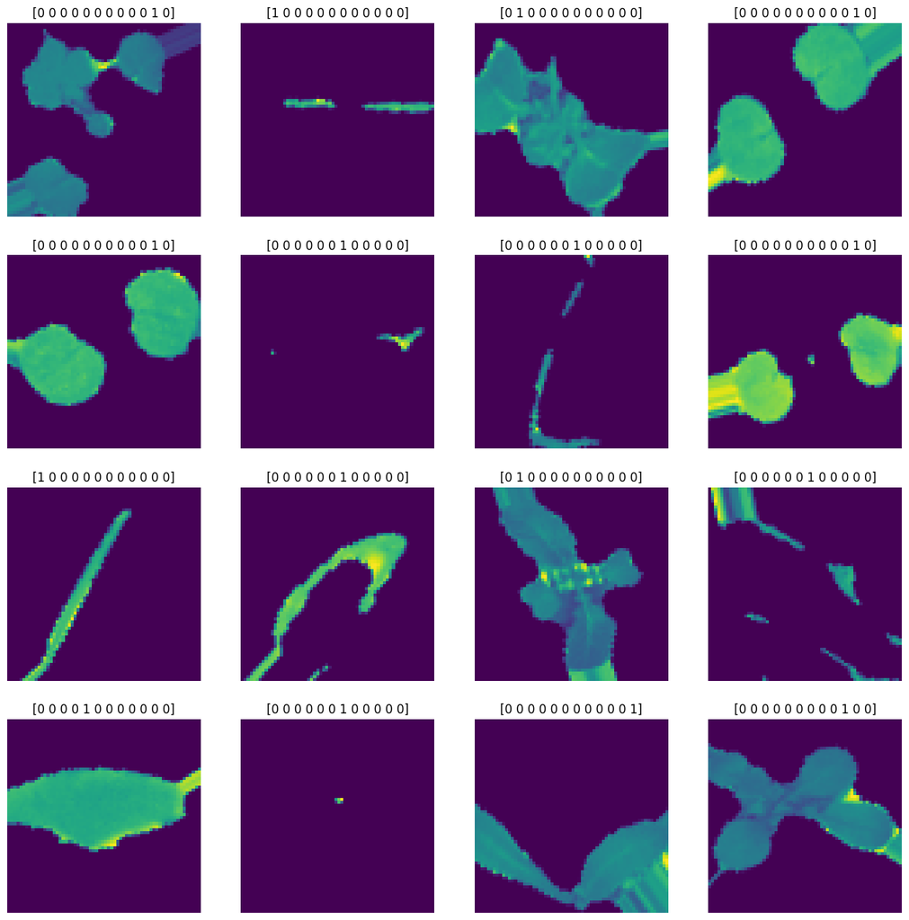

```python
images, data_labels = next(training_generator_gs)
fig, axes = plt.subplots(4,4, figsize= (16,8))
fig.set_size_inches(16,16)
for (image, label, ax) in zip(images, data_labels, axes.flatten()):
  ax.imshow(image)
  ax.set_title(label)
  ax.axis('off')
```

```python
new_model()
```

```python
model3 = Sequential()

#Input Layer
model3.add(Conv2D(32, (3,3), activation='relu', padding='same', input_shape=(64, 64, 1)))
# Add MaxPooling an additional convolutional layer and then pooling a second time
model3.add(BatchNormalization())
model3.add(MaxPooling2D((2, 2), padding = 'same'))

# Add a second convolution layer
model3.add(Conv2D(64, (3,3), activation='relu', padding='same'))
model3.add(BatchNormalization())
model3.add(MaxPooling2D((2, 2), padding = 'same'))

# Add a third convolution layer
model3.add(Conv2D(64, (3,3), activation='relu', padding='valid'))
model3.add(BatchNormalization())
model3.add(MaxPooling2D((2, 2), padding = 'valid'))

# Flatten
model3.add(Flatten())

# Adding the first fully connected hidden layer
model3.add(Dense(512, activation='relu'))
model3.add(Dropout(0.2))

# Adding a second fully connected hidden layer
model3.add(Dense(256, activation='relu'))


# Output Layer
model3.add(Dense(12, activation='softmax'))

optimizer = Adam(learning_rate=0.001)

model3.compile(optimizer=optimizer, loss='categorical_crossentropy', metrics=['accuracy'])

model3.summary()
```

```
Model: "sequential"
_________________________________________________________________
 Layer (type)                Output Shape              Param #
=================================================================
 conv2d (Conv2D)             (None, 64, 64, 32)        320

 batch_normalization (BatchN  (None, 64, 64, 32)       128
 ormalization)

 max_pooling2d (MaxPooling2D  (None, 32, 32, 32)       0
 )

 conv2d_1 (Conv2D)           (None, 32, 32, 64)        18496

 batch_normalization_1 (Batc  (None, 32, 32, 64)       256
 hNormalization)

 max_pooling2d_1 (MaxPooling  (None, 16, 16, 64)       0
 2D)

 conv2d_2 (Conv2D)           (None, 14, 14, 64)        36928

 batch_normalization_2 (Batc  (None, 14, 14, 64)       256
 hNormalization)

 max_pooling2d_2 (MaxPooling  (None, 7, 7, 64)         0
 2D)

 flatten (Flatten)           (None, 3136)              0

 dense (Dense)               (None, 512)               1606144

 dropout (Dropout)           (None, 512)               0

 dense_1 (Dense)             (None, 256)               131328

 dense_2 (Dense)             (None, 12)                3084

=================================================================
Total params: 1,796,940
Trainable params: 1,796,620
Non-trainable params: 320
_________________________________________________________________
```

## Fit the model on the train data with the class_weights and early stopping

```python
callback_escape = keras.callbacks.EarlyStopping(monitor='val_accuracy',
                                                patience=20,
                                                min_delta=0.001,
                                                restore_best_weights=True
                                              )

batch_size = 32
epochs = 150
```

```python
history3 = model3.fit(
    training_generator_gs,
    epochs=epochs,
    validation_data=(X_val_normalized_gs, y_val_encoded_gs),
    class_weight=class_weights,
    shuffle=True,
    verbose=2,
    callbacks = [callback_escape]
)
```

```
95/95 - 3s - loss: 2.4239 - accuracy: 0.3240 - val_loss: 15.0339 - val_accuracy: 0.0605 - 3s/epoch - 28ms/step
95/95 - 2s - loss: 1.9489 - accuracy: 0.3868 - val_loss: 34.1757 - val_accuracy: 0.0605 - 2s/epoch - 18ms/step
95/95 - 2s - loss: 1.7833 - accuracy: 0.4385 - val_loss: 42.5303 - val_accuracy: 0.0605 - 2s/epoch - 18ms/step
95/95 - 2s - loss: 1.6695 - accuracy: 0.4609 - val_loss: 33.1931 - val_accuracy: 0.0605 - 2s/epoch - 18ms/step
95/95 - 2s - loss: 1.6114 - accuracy: 0.4809 - val_loss: 20.0346 - val_accuracy: 0.0605 - 2s/epoch - 18ms/step
95/95 - 2s - loss: 1.4937 - accuracy: 0.5243 - val_loss: 6.9495 - val_accuracy: 0.0737 - 2s/epoch - 18ms/step
95/95 - 2s - loss: 1.4624 - accuracy: 0.5230 - val_loss: 2.2749 - val_accuracy: 0.3395 - 2s/epoch - 18ms/step
95/95 - 2s - loss: 1.4135 - accuracy: 0.5382 - val_loss: 1.2405 - val_accuracy: 0.5684 - 2s/epoch - 18ms/step
95/95 - 2s - loss: 1.3199 - accuracy: 0.5651 - val_loss: 1.6245 - val_accuracy: 0.4434 - 2s/epoch - 17ms/step
95/95 - 2s - loss: 1.2996 - accuracy: 0.5819 - val_loss: 1.7063 - val_accuracy: 0.4355 - 2s/epoch - 18ms/step
95/95 - 2s - loss: 1.2273 - accuracy: 0.5961 - val_loss: 3.5398 - val_accuracy: 0.2526 - 2s/epoch - 19ms/step
95/95 - 2s - loss: 1.1996 - accuracy: 0.6112 - val_loss: 1.1403 - val_accuracy: 0.5868 - 2s/epoch - 21ms/step
95/95 - 2s - loss: 1.1956 - accuracy: 0.6000 - val_loss: 1.3259 - val_accuracy: 0.5461 - 2s/epoch - 18ms/step
95/95 - 2s - loss: 1.1220 - accuracy: 0.6286 - val_loss: 1.2975 - val_accuracy: 0.5342 - 2s/epoch - 18ms/step
95/95 - 2s - loss: 1.1107 - accuracy: 0.6365 - val_loss: 2.5685 - val_accuracy: 0.3500 - 2s/epoch - 18ms/step
95/95 - 2s - loss: 1.0587 - accuracy: 0.6411 - val_loss: 1.4429 - val_accuracy: 0.5211 - 2s/epoch - 18ms/step
95/95 - 2s - loss: 1.0498 - accuracy: 0.6487 - val_loss: 0.8987 - val_accuracy: 0.6895 - 2s/epoch - 18ms/step
95/95 - 2s - loss: 1.0193 - accuracy: 0.6507 - val_loss: 0.9699 - val_accuracy: 0.6461 - 2s/epoch - 18ms/step
95/95 - 2s - loss: 0.9938 - accuracy: 0.6618 - val_loss: 1.3009 - val_accuracy: 0.5921 - 2s/epoch - 18ms/step
95/95 - 2s - loss: 0.9742 - accuracy: 0.6770 - val_loss: 0.7953 - val_accuracy: 0.7184 - 2s/epoch - 18ms/step
95/95 - 2s - loss: 0.9703 - accuracy: 0.6776 - val_loss: 1.1723 - val_accuracy: 0.5882 - 2s/epoch - 17ms/step
95/95 - 2s - loss: 0.9362 - accuracy: 0.6941 - val_loss: 1.4383 - val_accuracy: 0.5947 - 2s/epoch - 17ms/step
95/95 - 2s - loss: 0.9391 - accuracy: 0.6799 - val_loss: 2.0591 - val_accuracy: 0.4250 - 2s/epoch - 18ms/step
95/95 - 2s - loss: 0.9163 - accuracy: 0.6921 - val_loss: 1.5596 - val_accuracy: 0.5276 - 2s/epoch - 17ms/step
95/95 - 2s - loss: 0.8756 - accuracy: 0.7003 - val_loss: 1.6778 - val_accuracy: 0.5355 - 2s/epoch - 17ms/step
95/95 - 2s - loss: 0.8911 - accuracy: 0.7026 - val_loss: 1.0783 - val_accuracy: 0.6645 - 2s/epoch - 18ms/step
95/95 - 2s - loss: 0.8406 - accuracy: 0.7125 - val_loss: 1.4254 - val_accuracy: 0.5829 - 2s/epoch - 18ms/step
95/95 - 2s - loss: 0.8571 - accuracy: 0.7089 - val_loss: 0.8284 - val_accuracy: 0.7434 - 2s/epoch - 18ms/step
95/95 - 2s - loss: 0.8173 - accuracy: 0.7211 - val_loss: 0.8296 - val_accuracy: 0.7066 - 2s/epoch - 17ms/step
95/95 - 2s - loss: 0.7979 - accuracy: 0.7293 - val_loss: 0.8607 - val_accuracy: 0.7026 - 2s/epoch - 17ms/step
95/95 - 2s - loss: 0.8373 - accuracy: 0.7056 - val_loss: 0.8199 - val_accuracy: 0.7329 - 2s/epoch - 18ms/step
95/95 - 2s - loss: 0.7734 - accuracy: 0.7345 - val_loss: 1.0639 - val_accuracy: 0.6632 - 2s/epoch - 17ms/step
95/95 - 2s - loss: 0.7659 - accuracy: 0.7385 - val_loss: 0.8558 - val_accuracy: 0.7184 - 2s/epoch - 18ms/step
95/95 - 2s - loss: 0.7658 - accuracy: 0.7316 - val_loss: 1.3480 - val_accuracy: 0.6105 - 2s/epoch - 18ms/step
95/95 - 2s - loss: 0.7265 - accuracy: 0.7461 - val_loss: 0.8773 - val_accuracy: 0.6961 - 2s/epoch - 18ms/step
95/95 - 2s - loss: 0.7156 - accuracy: 0.7520 - val_loss: 0.8784 - val_accuracy: 0.6974 - 2s/epoch - 18ms/step
95/95 - 2s - loss: 0.7450 - accuracy: 0.7461 - val_loss: 2.2019 - val_accuracy: 0.4789 - 2s/epoch - 18ms/step
95/95 - 2s - loss: 0.7379 - accuracy: 0.7493 - val_loss: 1.0469 - val_accuracy: 0.6579 - 2s/epoch - 18ms/step
95/95 - 2s - loss: 0.7262 - accuracy: 0.7599 - val_loss: 1.0207 - val_accuracy: 0.6579 - 2s/epoch - 17ms/step
95/95 - 2s - loss: 0.7005 - accuracy: 0.7530 - val_loss: 0.7417 - val_accuracy: 0.7474 - 2s/epoch - 17ms/step
```

[output cut: 39 more lines]

```
95/95 - 2s - loss: 0.5249 - accuracy: 0.8171 - val_loss: 0.6108 - val_accuracy: 0.7961 - 2s/epoch - 17ms/step
95/95 - 2s - loss: 0.5464 - accuracy: 0.8145 - val_loss: 1.4168 - val_accuracy: 0.6224 - 2s/epoch - 17ms/step
95/95 - 2s - loss: 0.5064 - accuracy: 0.8234 - val_loss: 0.6301 - val_accuracy: 0.7961 - 2s/epoch - 17ms/step
95/95 - 2s - loss: 0.4935 - accuracy: 0.8243 - val_loss: 0.6757 - val_accuracy: 0.7961 - 2s/epoch - 17ms/step
95/95 - 2s - loss: 0.4750 - accuracy: 0.8293 - val_loss: 0.7558 - val_accuracy: 0.7447 - 2s/epoch - 18ms/step
95/95 - 2s - loss: 0.4946 - accuracy: 0.8224 - val_loss: 0.8542 - val_accuracy: 0.7079 - 2s/epoch - 18ms/step
95/95 - 2s - loss: 0.4802 - accuracy: 0.8243 - val_loss: 0.7491 - val_accuracy: 0.7750 - 2s/epoch - 18ms/step
95/95 - 2s - loss: 0.4949 - accuracy: 0.8178 - val_loss: 0.5597 - val_accuracy: 0.8079 - 2s/epoch - 18ms/step
95/95 - 2s - loss: 0.4869 - accuracy: 0.8270 - val_loss: 0.9936 - val_accuracy: 0.6789 - 2s/epoch - 18ms/step
95/95 - 2s - loss: 0.4826 - accuracy: 0.8250 - val_loss: 0.6535 - val_accuracy: 0.7816 - 2s/epoch - 18ms/step
95/95 - 2s - loss: 0.4693 - accuracy: 0.8309 - val_loss: 0.7192 - val_accuracy: 0.7724 - 2s/epoch - 18ms/step
95/95 - 2s - loss: 0.4814 - accuracy: 0.8197 - val_loss: 0.7316 - val_accuracy: 0.7487 - 2s/epoch - 18ms/step
95/95 - 2s - loss: 0.4593 - accuracy: 0.8378 - val_loss: 0.6008 - val_accuracy: 0.8118 - 2s/epoch - 18ms/step
95/95 - 2s - loss: 0.4742 - accuracy: 0.8243 - val_loss: 0.9361 - val_accuracy: 0.7145 - 2s/epoch - 17ms/step
95/95 - 2s - loss: 0.4988 - accuracy: 0.8217 - val_loss: 2.8942 - val_accuracy: 0.4303 - 2s/epoch - 18ms/step
```

## Model3 Evaluation

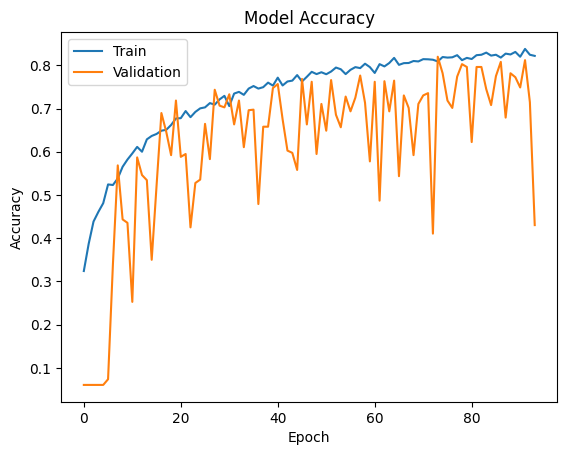

```python
plt.plot(history3.history['accuracy'])
plt.plot(history3.history['val_accuracy'])
plt.title('Model Accuracy')
plt.ylabel('Accuracy')
plt.xlabel('Epoch')
plt.legend(['Train', 'Validation'], loc='upper left')
plt.show()
```

### Notes:

```python
accuracy3 = model3.evaluate(X_test_normalized_gs, y_test_encoded_gs)
print(f"test accuracy: {accuracy3}")
```

```
test accuracy: [0.6304884552955627, 0.7831578850746155]
```

```python
best_model_accuracy3 = history3.history['accuracy'][np.argmin(history3.history['loss'])]
print(f"best model accuracy (with the least loss): {best_model_accuracy3}")
```

```
best model accuracy (with the least loss): 0.8378289341926575
```

## Prediction based on test data

```python
y_pred3 = model3.predict(X_test_normalized_gs)
```

```python
y_pred3
```

```
array([[9.37107295e-25, 3.05681569e-09, 2.20229474e-10, ...,
        4.99735929e-15, 1.00000000e+00, 1.13772489e-18],
       [4.79471684e-02, 1.51804180e-10, 7.35137462e-08, ...,
        1.33321674e-12, 1.50062615e-05, 9.90391982e-06],
       [1.35416060e-21, 7.96698878e-05, 2.01718340e-08, ...,
        1.39421905e-12, 9.99920249e-01, 4.01005382e-17],
       ...,
       [9.85749134e-13, 6.58487096e-08, 2.14088246e-07, ...,
        1.09260785e-04, 5.96910965e-08, 9.69672875e-09],
       [7.79218317e-06, 1.84273534e-02, 9.79591429e-01, ...,
        4.57099144e-04, 1.62793891e-04, 4.33582045e-06],
       [2.92973326e-08, 8.47813135e-05, 9.99012947e-01, ...,
        2.97092320e-05, 4.21119476e-04, 3.08985764e-05]], dtype=float32)
```

## Prediction Confusion Matrix

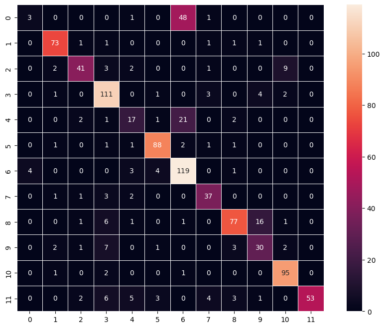

```python
y_pred3_arg=np.argmax(y_pred3, axis=1)
y_test3_arg=np.argmax(y_test_encoded_gs, axis=1)

confusion_matrix3 = tf.math.confusion_matrix(y_test3_arg, y_pred3_arg)
f, ax = plt.subplots(figsize=(12,8))
sns.heatmap(
    confusion_matrix3, annot=True, linewidths=.4,
    fmt='d', square=True, ax=ax
)
plt.show()
```

### Notes:

- Grayscale seems to have performed worse than the color images
- Class 6 takes the top spot followed closely by Class 3 and then 10, but these are the only classes with more than 90 correct classification
- Class 4 and 0 have the lowest classification

## Model3 Conclusion

- This model using grayscale images does not looks to be overfit but is only marginal for making predictions. Model 2 was much more accurate

# Model 4 Transfer Learning Using VGG16

```python
new_model()
```

```python
vgg_model = VGG16(weights='imagenet', include_top = False, input_shape = (64,64,3))
vgg_model.summary()
```

```
Model: "vgg16"
_________________________________________________________________
 Layer (type)                Output Shape              Param #
=================================================================
 input_1 (InputLayer)        [(None, 64, 64, 3)]       0

 block1_conv1 (Conv2D)       (None, 64, 64, 64)        1792

 block1_conv2 (Conv2D)       (None, 64, 64, 64)        36928

 block1_pool (MaxPooling2D)  (None, 32, 32, 64)        0

 block2_conv1 (Conv2D)       (None, 32, 32, 128)       73856

 block2_conv2 (Conv2D)       (None, 32, 32, 128)       147584

 block2_pool (MaxPooling2D)  (None, 16, 16, 128)       0

 block3_conv1 (Conv2D)       (None, 16, 16, 256)       295168

 block3_conv2 (Conv2D)       (None, 16, 16, 256)       590080

 block3_conv3 (Conv2D)       (None, 16, 16, 256)       590080

 block3_pool (MaxPooling2D)  (None, 8, 8, 256)         0

 block4_conv1 (Conv2D)       (None, 8, 8, 512)         1180160

 block4_conv2 (Conv2D)       (None, 8, 8, 512)         2359808

 block4_conv3 (Conv2D)       (None, 8, 8, 512)         2359808

 block4_pool (MaxPooling2D)  (None, 4, 4, 512)         0

 block5_conv1 (Conv2D)       (None, 4, 4, 512)         2359808

 block5_conv2 (Conv2D)       (None, 4, 4, 512)         2359808

 block5_conv3 (Conv2D)       (None, 4, 4, 512)         2359808

 block5_pool (MaxPooling2D)  (None, 2, 2, 512)         0

=================================================================
Total params: 14,714,688
Trainable params: 14,714,688
Non-trainable params: 0
_________________________________________________________________
```

```python
## Make the imported layers non-trainable
for layer in vgg_model.layers:
  layer.trainable = False
```

```python
vgg_new_model = Sequential()

# Add the convolutional part of VGG16
vgg_new_model.add(vgg_model)

vgg_new_model.add(Flatten())

vgg_new_model.add(Dense(32, activation='relu'))
vgg_new_model.add(Dropout(0.2))
vgg_new_model.add(Dense(16, activation='relu'))
vgg_new_model.add(Dense(12, activation='softmax'))

optimizer = Adam()

vgg_new_model.compile(optimizer=optimizer, loss='categorical_crossentropy', metrics=['accuracy'])

vgg_new_model.summary()
```

```
Model: "sequential"
_________________________________________________________________
 Layer (type)                Output Shape              Param #
=================================================================
 vgg16 (Functional)          (None, 2, 2, 512)         14714688

 flatten (Flatten)           (None, 2048)              0

 dense (Dense)               (None, 32)                65568

 dropout (Dropout)           (None, 32)                0

 dense_1 (Dense)             (None, 16)                528

 dense_2 (Dense)             (None, 12)                204

=================================================================
Total params: 14,780,988
Trainable params: 66,300
Non-trainable params: 14,714,688
_________________________________________________________________
```

```python
epochs = 50
batch_size = 32

history4 = vgg_new_model.fit(training_generator,
                         epochs=epochs,
                         steps_per_epoch=X_train_normalized.shape[0] // batch_size,
                         validation_data=(X_val_normalized,y_val_encoded),
                         verbose=2)
```

```
95/95 - 5s - loss: 2.2110 - accuracy: 0.2520 - val_loss: 1.8583 - val_accuracy: 0.4079 - 5s/epoch - 52ms/step
95/95 - 4s - loss: 1.7347 - accuracy: 0.4118 - val_loss: 1.4490 - val_accuracy: 0.4829 - 4s/epoch - 38ms/step
95/95 - 4s - loss: 1.4984 - accuracy: 0.4786 - val_loss: 1.2467 - val_accuracy: 0.5789 - 4s/epoch - 37ms/step
95/95 - 4s - loss: 1.3524 - accuracy: 0.5224 - val_loss: 1.0927 - val_accuracy: 0.6408 - 4s/epoch - 38ms/step
95/95 - 4s - loss: 1.2985 - accuracy: 0.5447 - val_loss: 1.0918 - val_accuracy: 0.6447 - 4s/epoch - 38ms/step
95/95 - 4s - loss: 1.2378 - accuracy: 0.5757 - val_loss: 1.0259 - val_accuracy: 0.6618 - 4s/epoch - 38ms/step
95/95 - 4s - loss: 1.1834 - accuracy: 0.5819 - val_loss: 0.9921 - val_accuracy: 0.6618 - 4s/epoch - 38ms/step
95/95 - 4s - loss: 1.1584 - accuracy: 0.5924 - val_loss: 0.9611 - val_accuracy: 0.6829 - 4s/epoch - 38ms/step
95/95 - 4s - loss: 1.1136 - accuracy: 0.6155 - val_loss: 0.9098 - val_accuracy: 0.6947 - 4s/epoch - 40ms/step
95/95 - 4s - loss: 1.1074 - accuracy: 0.6132 - val_loss: 0.8858 - val_accuracy: 0.7066 - 4s/epoch - 37ms/step
95/95 - 4s - loss: 1.0738 - accuracy: 0.6220 - val_loss: 0.8377 - val_accuracy: 0.7158 - 4s/epoch - 38ms/step
95/95 - 4s - loss: 1.0403 - accuracy: 0.6484 - val_loss: 0.9168 - val_accuracy: 0.6697 - 4s/epoch - 38ms/step
95/95 - 4s - loss: 1.0486 - accuracy: 0.6263 - val_loss: 0.8042 - val_accuracy: 0.7184 - 4s/epoch - 38ms/step
95/95 - 4s - loss: 1.0140 - accuracy: 0.6398 - val_loss: 0.8285 - val_accuracy: 0.7197 - 4s/epoch - 38ms/step
95/95 - 4s - loss: 1.0036 - accuracy: 0.6431 - val_loss: 0.8107 - val_accuracy: 0.7039 - 4s/epoch - 38ms/step
95/95 - 4s - loss: 1.0040 - accuracy: 0.6609 - val_loss: 0.8022 - val_accuracy: 0.7171 - 4s/epoch - 38ms/step
95/95 - 4s - loss: 0.9810 - accuracy: 0.6507 - val_loss: 0.7950 - val_accuracy: 0.7132 - 4s/epoch - 38ms/step
95/95 - 4s - loss: 0.9613 - accuracy: 0.6526 - val_loss: 0.7576 - val_accuracy: 0.7408 - 4s/epoch - 38ms/step
95/95 - 4s - loss: 0.9617 - accuracy: 0.6576 - val_loss: 0.7948 - val_accuracy: 0.7250 - 4s/epoch - 38ms/step
95/95 - 4s - loss: 0.9645 - accuracy: 0.6605 - val_loss: 0.8116 - val_accuracy: 0.7211 - 4s/epoch - 37ms/step
95/95 - 4s - loss: 0.9477 - accuracy: 0.6645 - val_loss: 0.7561 - val_accuracy: 0.7382 - 4s/epoch - 38ms/step
95/95 - 4s - loss: 0.9454 - accuracy: 0.6609 - val_loss: 0.7568 - val_accuracy: 0.7421 - 4s/epoch - 38ms/step
95/95 - 4s - loss: 0.9240 - accuracy: 0.6632 - val_loss: 0.7665 - val_accuracy: 0.7329 - 4s/epoch - 38ms/step
95/95 - 4s - loss: 0.9208 - accuracy: 0.6743 - val_loss: 0.7470 - val_accuracy: 0.7513 - 4s/epoch - 37ms/step
95/95 - 4s - loss: 0.8990 - accuracy: 0.6687 - val_loss: 0.7816 - val_accuracy: 0.7250 - 4s/epoch - 37ms/step
95/95 - 4s - loss: 0.8882 - accuracy: 0.6789 - val_loss: 0.7295 - val_accuracy: 0.7395 - 4s/epoch - 38ms/step
95/95 - 4s - loss: 0.9019 - accuracy: 0.6757 - val_loss: 0.7047 - val_accuracy: 0.7553 - 4s/epoch - 38ms/step
95/95 - 4s - loss: 0.8920 - accuracy: 0.6819 - val_loss: 0.7312 - val_accuracy: 0.7461 - 4s/epoch - 37ms/step
95/95 - 4s - loss: 0.8999 - accuracy: 0.6691 - val_loss: 0.7187 - val_accuracy: 0.7645 - 4s/epoch - 39ms/step
95/95 - 4s - loss: 0.8800 - accuracy: 0.6776 - val_loss: 0.7039 - val_accuracy: 0.7592 - 4s/epoch - 39ms/step
95/95 - 4s - loss: 0.8739 - accuracy: 0.6888 - val_loss: 0.6814 - val_accuracy: 0.7711 - 4s/epoch - 38ms/step
95/95 - 4s - loss: 0.8681 - accuracy: 0.6908 - val_loss: 0.7004 - val_accuracy: 0.7513 - 4s/epoch - 38ms/step
95/95 - 4s - loss: 0.8735 - accuracy: 0.6905 - val_loss: 0.7341 - val_accuracy: 0.7382 - 4s/epoch - 38ms/step
95/95 - 4s - loss: 0.8568 - accuracy: 0.6891 - val_loss: 0.7121 - val_accuracy: 0.7566 - 4s/epoch - 38ms/step
95/95 - 4s - loss: 0.8700 - accuracy: 0.6918 - val_loss: 0.6560 - val_accuracy: 0.7855 - 4s/epoch - 38ms/step
95/95 - 4s - loss: 0.8388 - accuracy: 0.6993 - val_loss: 0.7073 - val_accuracy: 0.7645 - 4s/epoch - 38ms/step
95/95 - 4s - loss: 0.8460 - accuracy: 0.6934 - val_loss: 0.7129 - val_accuracy: 0.7579 - 4s/epoch - 37ms/step
95/95 - 4s - loss: 0.8445 - accuracy: 0.7049 - val_loss: 0.7036 - val_accuracy: 0.7539 - 4s/epoch - 37ms/step
95/95 - 4s - loss: 0.8415 - accuracy: 0.6918 - val_loss: 0.6754 - val_accuracy: 0.7671 - 4s/epoch - 38ms/step
95/95 - 4s - loss: 0.8336 - accuracy: 0.6931 - val_loss: 0.7123 - val_accuracy: 0.7487 - 4s/epoch - 37ms/step
95/95 - 4s - loss: 0.8348 - accuracy: 0.7000 - val_loss: 0.7128 - val_accuracy: 0.7539 - 4s/epoch - 38ms/step
95/95 - 4s - loss: 0.8255 - accuracy: 0.7016 - val_loss: 0.6736 - val_accuracy: 0.7684 - 4s/epoch - 37ms/step
95/95 - 4s - loss: 0.8278 - accuracy: 0.7039 - val_loss: 0.6966 - val_accuracy: 0.7487 - 4s/epoch - 38ms/step
95/95 - 4s - loss: 0.8192 - accuracy: 0.7122 - val_loss: 0.6540 - val_accuracy: 0.7750 - 4s/epoch - 37ms/step
95/95 - 4s - loss: 0.8300 - accuracy: 0.7072 - val_loss: 0.6824 - val_accuracy: 0.7605 - 4s/epoch - 38ms/step
95/95 - 4s - loss: 0.7893 - accuracy: 0.7174 - val_loss: 0.6699 - val_accuracy: 0.7618 - 4s/epoch - 38ms/step
95/95 - 4s - loss: 0.8264 - accuracy: 0.7069 - val_loss: 0.7014 - val_accuracy: 0.7474 - 4s/epoch - 38ms/step
95/95 - 4s - loss: 0.8147 - accuracy: 0.7023 - val_loss: 0.6718 - val_accuracy: 0.7684 - 4s/epoch - 38ms/step
95/95 - 4s - loss: 0.8174 - accuracy: 0.7086 - val_loss: 0.6872 - val_accuracy: 0.7579 - 4s/epoch - 37ms/step
95/95 - 4s - loss: 0.8280 - accuracy: 0.7030 - val_loss: 0.6463 - val_accuracy: 0.7750 - 4s/epoch - 38ms/step
```

## Model4 Evaluation

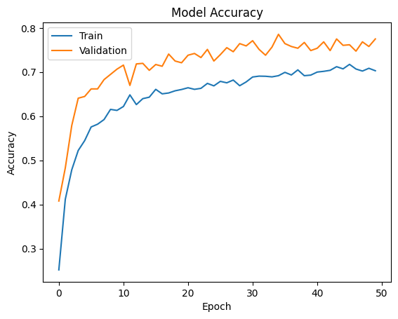

```python
plt.plot(history4.history['accuracy'])
plt.plot(history4.history['val_accuracy'])
plt.title('Model Accuracy')
plt.ylabel('Accuracy')
plt.xlabel('Epoch')
plt.legend(['Train', 'Validation'], loc='upper left')
plt.show()
```

### Notes:

- The accuracy validation was higher than train for the entire fit

```python
accuracy4 = vgg_new_model.evaluate(X_test_normalized, y_test_encoded)
print(f"test accuracy: {accuracy4}")
```

```
test accuracy: [0.7174263596534729, 0.7389473915100098]
```

```python
best_model_accuracy4 = history4.history['accuracy'][np.argmin(history4.history['loss'])]
print(f"best model accuracy (with the least loss): {best_model_accuracy4}")
```

```
best model accuracy (with the least loss): 0.7174342274665833
```

## Prediction based on test data

```python
y_pred4 = vgg_new_model.predict(X_test_normalized)
```

```python
y_pred4
```

```
array([[2.5364598e-08, 9.1199159e-05, 1.0429545e-04, ..., 1.9347810e-05,
        9.9923992e-01, 5.4772830e-05],
       [2.7998653e-01, 5.7812041e-08, 3.3098340e-07, ..., 4.8572408e-09,
        2.7446370e-07, 1.1867931e-05],
       [9.0985999e-08, 3.8283219e-04, 3.8953091e-04, ..., 1.8745866e-05,
        9.9856144e-01, 8.7847839e-05],
       ...,
       [3.4598749e-10, 4.5435657e-03, 1.4077444e-05, ..., 2.4674757e-01,
        3.6070747e-03, 1.4721166e-04],
       [1.5625326e-03, 3.1804854e-01, 2.9169577e-01, ..., 3.5907596e-02,
        2.8909530e-02, 2.4467485e-02],
       [2.3917528e-05, 4.3905202e-02, 9.3501264e-01, ..., 2.4743477e-04,
        4.9396846e-03, 4.2187932e-04]], dtype=float32)
```

## Prediction Confusion Matrix

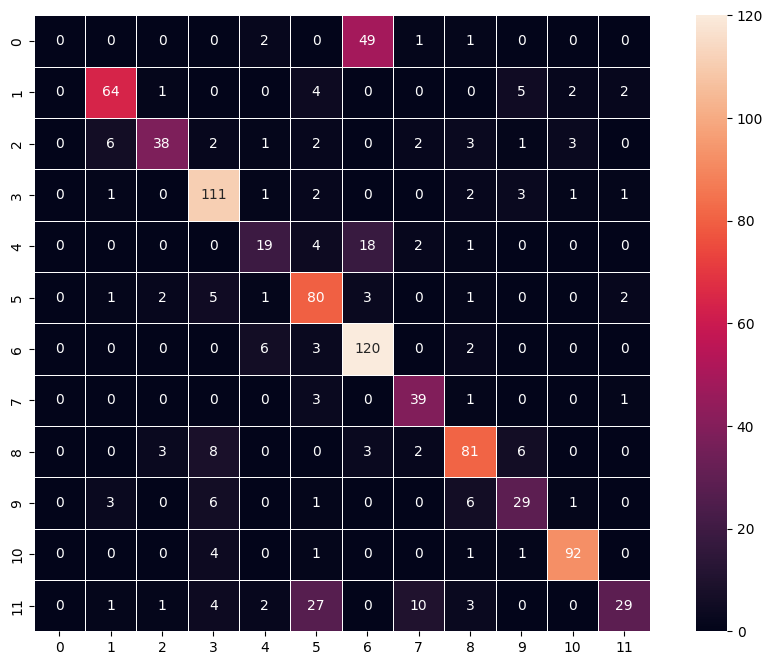

```python
y_pred4_arg=np.argmax(y_pred4, axis=1)
y_test4_arg=np.argmax(y_test_encoded, axis=1)

confusion_matrix4 = tf.math.confusion_matrix(y_test4_arg, y_pred4_arg)
f, ax = plt.subplots(figsize=(12,8))
sns.heatmap(
    confusion_matrix4, annot=True, linewidths=.4,
    fmt='d', square=True, ax=ax
)
plt.show()
```

### Notes:

- The vgg16 convolution settings using the color dataset seems to have performed worse than Model2 that used fewer params
- Class 6 takes the top spot followed closely by Class 3 and then 10 but these are the only classes with more than 90 correct classification
- Class 4, 0, 9, & 11 have the lowest successfult classifications

## Model4 Conclusion

- This model was back to using the color images that had been augmented but the VGG16 concolution portion did not help but actually hurt accuracy

```python
end_total = time.time()
print(f"\n\nTotal Runtime for the entire Notebook is {end_total - begin_total}")
```

```
Total Runtime for the entire Notebook is 642.56880402565
```

# Executive Summary of Analysis

## Conclusions

1. Of the four CNN models created only Model2 performed well enough for prediction

[output not shown]

2. A CNN with 1 input layer, 2 convolutional layers with batch normalization, maxpolling and dropout (not all together), 2 fully connected layers, and 1 output layer achieved the highest accuract of 88% on unseen test data.